# Exam 2

## Another Uber Experiment

Uber is (predominantly) a peer-to-peer ride sharing service that helps people get where they need to go by connecting passengers with drivers. The passenger requests a ride using the Uber app and then a matching algorithm matches the passenger with a nearby driver who is available to provide the ride. For the convenience of both the passenger and the driver it is important that the matching algorithm makes sensible connections. If the algorithm matches a passenger to a driver that is very far away the passenger may cancel the ride and use a competitor ride sharing app with a closer driver. Similarly, if the driver gets matched to a passenger whose destination is much further away than they intend to drive they may cancel the ride and wait for their next match. The data science team at Uber is experimenting with the machine learning algorithm that performs the matching. By tuning various hyperparameters the team has developed four versions of the matching algorithm that they wish to experiment with. Specifically, they wish to determine which version (labeled 1, 2, 3, 4) of the algorithm minimizes the “cancel-rate”: the proportion of rides that are canceled (by either passengers or drivers) once the match has been made.

```r
df<-read.csv("uber.csv")
library(tidyverse)

df_long <- df %>% pivot_longer(everything(),
                               names_to="treatment",
                               values_to="cancel")

df_long %>% group_by(treatment, cancel) %>% summarise(n=n()) %>% mutate(freq=n/sum(n))
```

```
## # A tibble: 8 × 4
## # Groups:   treatment [4]
##   treatment cancel     n   freq
##   <chr>      <int> <int>  <dbl>
## 1 alg1           0  2859 0.953
## 2 alg1           1   141 0.047
## 3 alg2           0  2809 0.936
## 4 alg2           1   191 0.0637
## 5 alg3           0  2898 0.966
## 6 alg3           1   102 0.034
## 7 alg4           0  2910 0.97
## 8 alg4           1    90 0.03
```

### Analysis 1

```r
df_long$treatment<-as.factor(df_long$treatment)
mod<-glm(cancel~treatment, data=df_long, family="binomial")
anova(mod, test = "Chisq")
```

```
## Analysis of Deviance Table
##
## Model: binomial, link: logit
##
## Response: cancel
##
## Terms added sequentially (first to last)
##
##
##           Df Deviance Resid. Df Resid. Dev  Pr(>Chi)
## NULL                      11999     4306.2
## treatment  3   48.346     11996     4257.9 1.797e-10 ***
## ---
## Signif. codes:  0 '***' 0.001 '**' 0.01 '*' 0.05 '.' 0.1 ' ' 1
```

```r
library(multcomp)
comps<-glht(mod, linfct = mcp(treatment="Tukey"))
summary(comps)
```

```
##
##   Simultaneous Tests for General Linear Hypotheses
##
## Multiple Comparisons of Means: Tukey Contrasts
##
##
## Fit: glm(formula = cancel ~ treatment, family = "binomial", data = df_long)
##
## Linear Hypotheses:
##                  Estimate Std. Error z value Pr(>|z|)
## alg2 - alg1 == 0   0.3212     0.1142   2.813  0.02500 *
## alg3 - alg1 == 0  -0.3373     0.1326  -2.543  0.05290 .
## alg4 - alg1 == 0  -0.4666     0.1375  -3.395  0.00387 **
## alg3 - alg2 == 0  -0.6585     0.1255  -5.249  < 0.001 ***
## alg4 - alg2 == 0  -0.7878     0.1306  -6.034  < 0.001 ***
## alg4 - alg3 == 0  -0.1293     0.1470  -0.880  0.81410
## ---
## Signif. codes:  0 '***' 0.001 '**' 0.01 '*' 0.05 '.' 0.1 ' ' 1
## (Adjusted p values reported -- single-step method)
```

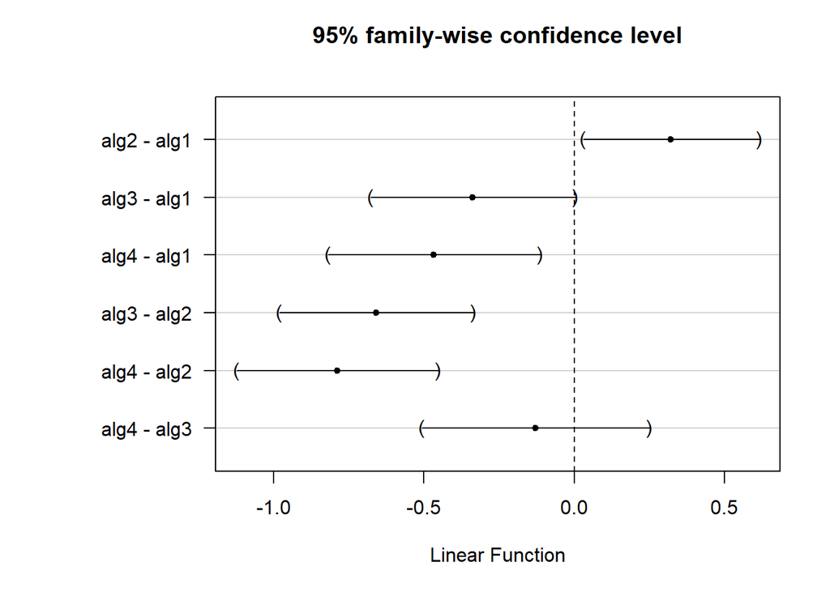

```r
par(oma = c(0, 5, 0, 0))
plot(comps)
```

### Analysis 2

```r
summary(mod)
```

```
##
## Call:
## glm(formula = cancel ~ treatment, family = "binomial", data = df_long)
##
## Coefficients:
##               Estimate Std. Error z value Pr(>|z|)
## (Intercept)   -3.00947    0.08627 -34.886  < 2e-16 ***
## treatmentalg2  0.32116    0.11416   2.813 0.004907 **
## treatmentalg3 -0.33734    0.13263  -2.543 0.010977 *
## treatmentalg4 -0.46663    0.13747  -3.395 0.000687 ***
## ---
## Signif. codes:  0 '***' 0.001 '**' 0.01 '*' 0.05 '.' 0.1 ' ' 1
##
## (Dispersion parameter for binomial family taken to be 1)
##
##     Null deviance: 4306.2  on 11999  degrees of freedom
## Residual deviance: 4257.9  on 11996  degrees of freedom
## AIC: 4265.9
##
## Number of Fisher Scoring iterations: 6
```

## Yield Experiment

The yield of a chemical process is being studied. The two most important variables are thought to be the pressure and the temperature. Three levels of each factor are selected, and a factorial experiment with two replicates is performed.

```r
df<-read.csv("yield.csv")
library(tidyverse)
df_long <- df %>% pivot_longer(!Temperature,
                               names_to="Pressure",
                               values_to="Response")
df_long
```

```
## # A tibble: 18 × 3
##    Temperature Pressure     Response
##          <int> <chr>           <dbl>
##  1         150 Pressure.200     90.4
##  2         150 Pressure.215     90.7
##  3         150 Pressure.230     90.2
##  4         150 Pressure.200     90.2
##  5         150 Pressure.215     90.6
##  6         150 Pressure.230     90.4
##  7         160 Pressure.200     90.1
##  8         160 Pressure.215     90.5
##  9         160 Pressure.230     89.9
## 10         160 Pressure.200     90.3
## 11         160 Pressure.215     90.6
## 12         160 Pressure.230     90.1
## 13         170 Pressure.200     90.5
## 14         170 Pressure.215     90.8
## 15         170 Pressure.230     90.4
## 16         170 Pressure.200     90.7
## 17         170 Pressure.215     90.9
## 18         170 Pressure.230     90.1
```

```r
df_long$Temperature<-as.factor(df_long$Temperature)
df_long$Pressure<-as.factor(df_long$Pressure)
mod<-aov(Response~Temperature*Pressure, data=df_long)
summary(mod)
```

```
##                      Df Sum Sq Mean Sq F value   Pr(>F)
## Temperature           2 0.3011  0.1506   8.469 0.008539 **
## Pressure              2 0.7678  0.3839  21.594 0.000367 ***
## Temperature:Pressure  4 0.0689  0.0172   0.969 0.470006
## Residuals             9 0.1600  0.0178
## ---
## Signif. codes:  0 '***' 0.001 '**' 0.01 '*' 0.05 '.' 0.1 ' ' 1
```

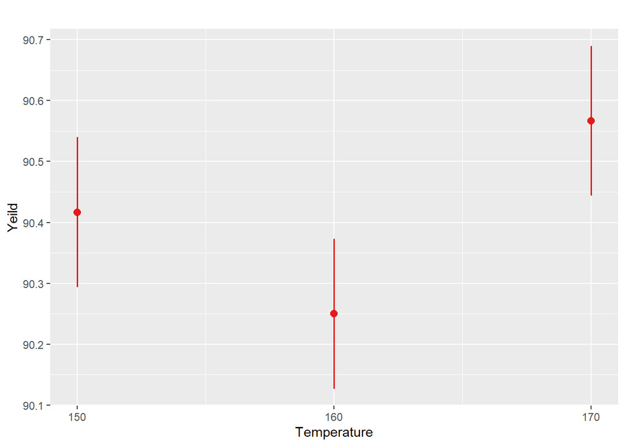

```r
library(sjPlot)
plot_model(mod, type="eff", terms=c("Temperature"), axis.title = ("Yeild"), title="" )
```

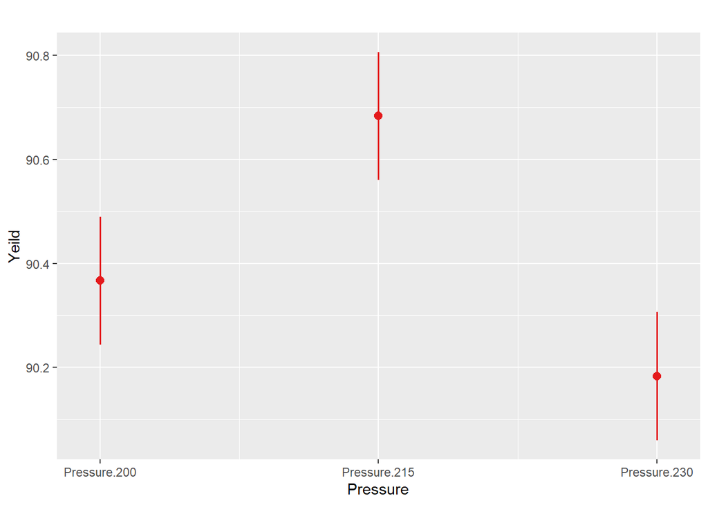

```r
plot_model(mod, type="eff", terms=c("Pressure"), axis.title = ("Yeild"), title="" )
```

## Helicopter Experiment

### Group 1

```r
df<-read.csv("trials.csv")
df
```

```
##    Measurements Time
## 1          5.5t 2.54
## 2         4.75t 2.00
## 3          5.5t 2.18
## 4          5.5t 2.00
## 5            4t 1.62
## 6            4t 1.86
## 7            6t 1.83
## 8            4t 1.61
## 9         4.75t 2.04
## 10           6t 1.74
## 11        4.75t 1.98
## 12           4t 1.91
## 13         5.5t 1.90
## 14           6t 1.66
## 15           4t 1.86
## 16         5.5t 2.11
## 17        4.75t 2.24
## 18           6t 2.17
## 19           6t 2.08
## 20        4.75t 1.78
```

## Group 2

```r
df<-read.csv("ExperimentFun.csv")
df
```

```
##     X WingLength Replicate Time
## 1   1       5.50         1 1.45
## 2   2       4.75         1 1.48
## 3   3       6.00         1 1.03
## 4   4       4.00         1 1.67
## 5   5       4.75         2 1.57
## 6   6       4.00         2 1.60
## 7   7       5.50         2 1.60
## 8   8       6.00         2 1.40
## 9   9       4.75         3 1.38
## 10 10       5.50         3 1.41
## 11 11       4.00         3 1.45
## 12 12       6.00         3 1.94
## 13 13       5.50         4 1.65
## 14 14       4.75         4 1.43
## 15 15       6.00         4 1.53
## 16 16       4.00         4 1.27
## 17 17       5.50         5 1.68
## 18 18       4.75         5 1.85
## 19 19       6.00         5 1.18
## 20 20       4.00         5 1.07
```